# Kürzeste Wege in Graphen & Tokenization

Schnell zum Ziel & Wie lesen Computer?

Dr. Kay Rottmann

Donnerstag, 07. November, 2024

# Einführung

## Überblick

- Dr. Kay Rottmann, Sr. Scientist @ Amazon  
  Diplom (2007) und Promotion (2013) in Informatik (am KIT)  
  Gastvorlesungen am KIT (Deep Learning, NLP), 2024 DHBW Karlsruhe (Digitale Sprachverarbeitung)  
  Parallel dazu: Startups, Facebook, Bosch, Amazon
- Ziele für heute
  - Finden von kürzesten Wegen in Graphen
    - Dijkstra’s Algorithmus verstehen und anwenden
  - Tokenization in Großen Sprachmodellen
    - Wie verstehen LLMs Text?

# Kürzeste Pfade in Graphen

## Grundlagen

- Graph
  - Knoten $\mathcal V$, Kanten $\mathcal E \subseteq \mathcal{VxV}$
  - ungerichtet: $(a,b) \in E \Leftrightarrow (b,a) \in E$
  - Gewichte: $e: \mathcal{E} \rightarrow \mathbb{R}$
- Darstellung im Speicher:
  - Adjazenzliste (für jeden Knoten Liste der Kanten)
  - Adjazenzmatrix (in Matrix $M$ an $M_{i,j}$ Kantengewicht von Knoten $i$ nach $j$)
- Pfad: Folge von Knoten $(v_1, \ldots, v_n)$ mit $\forall i < n: (v_i, v_{i+1}) \in \mathcal{E}$
- Oft wichtig: kürzester Pfad

[figure not shown]

Beispiel eines Graphen

## Kürzeste Pfade

- Was ist ein kürzester Pfad?
  - Pfad von Quelle (Source $S$) zum Ziel ($T$) dessen Summe der Gewichte an den Kanten minimal ist

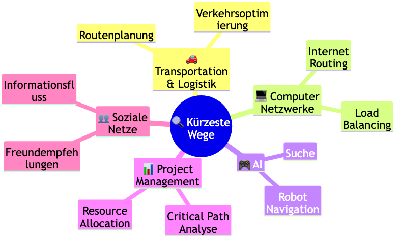

## Varianten

- Single Source (heute)
  - Sonderfall: Single Source, Single Target - gleiche Komplexität im Worst Case
- Alle-Paare
- negative Gewichte
  - z.B. Aufladen mit E-Fahrzeug
  - negative “Zyklen” möglich?

## Beispielgraph (pysikalische Motivation)

[interactive chart not shown]

## Dijkstra-Algorithmus Motivation

- Beobachtung: kürzeste Wege bestehen selbst nur aus kürzesten Teilwegen
- Idee: **Wenn für Knotenteilmenge optimale Wege zu ihnen bekannt** und kein Knoten ausserhalb der Menge schneller erreichbar ist, **erweitere diese Teilmenge um Knoten der (insgesamt) am kürzesten über eine Kante erreichbar**
- Dies geht effizient: Wann immer ein neuer kürzester Pfad zu neuem Knoten gefunden, betrachte ob Nachbarknoten über diesen Knoten schneller erreichbar sind.
- Wiederhole dies, bis alle Knoten bekannt, oder keine mehr erreichbar

[figure not shown]

## Dijkstra Implementation

```
Eingabe: Graph G = (V,E), Startknoten s, Kantengewichte e(u,v)
Ausgabe: Kürzeste Pfade p(v) und Längen l(v) von s zu allen v ∈ V


X := {}, l(s) := 0, l(v) :=  ∞ für v ≠ s

so lange wie X ≠ V:               // Hauptschleife
    x = argmin{l(x) | x ∈ V\X}    // Unbesuchter, nächster(!) Knoten

    falls l(x) == ∞ :
      break

    für alle y mit (x,y) ∈ E, y ∈ V\X:    // Für alle Nachbarn
      falls l(x) + e(x,y) < l(y):         // falls Weg zu y über x kürzer
        l(y) := l(x) + e(x,y)  // update Entfernung zu y
        p(y) := x                         // update Vorgänger von y
    X := X ∪ {x}

return p, l
```

## Dijkstra Simulation

[interactive chart not shown]

## Laufzeitanalyse Dijkstra

- Initialisierung: $\mathcal{O} (|V|)$
  - Jeder Knoten ist wird minimaler-Kosten-Knoten: $\mathcal{O} (|V|) \cdot T_\textrm{deleteMin}$
    1. update Entfernung zu Nachbarn: $\mathcal{O} (|E|) \cdot T_\textrm{decreaseKey}$
    2. falls nicht update, dann füg Knoten hinzu: $\mathcal{O} (|V|) \cdot T_\textrm{insert}$
- Gesamtlaufzeit ohne Optimierungen:
  - $\mathcal{O} (|E| \cdot T_\textrm{decreaseKey} + |V| \cdot ( T_\textrm{deleteMin} + T_\textrm{insert}))$
  - Naiv: ($\textrm{deleteMin}$) kostet $\mathcal{O}(|V|) ~$): $\mathcal{O} (|E| + |V|^2)$
- Optimiert:
  - Binary-Heap -> alle Operationen: $\mathcal{O}(\log V)$
  - $\Rightarrow$ Gesamtlaufzeit: $\mathcal{O}((|E|+|V|) \cdot \log V)$
  - (Fibonacci Heap noch besser)

## Zusammenfassung

- Dijkstra findet kürzeste Wege in Graphen mit nichtnegativen Kanten
- Bei negativen Kanten z.B. Bellman-Ford
- Weitere Optimierungen für Dijkstra in Single Source Single Target:
  - nutze $A^*$ Suche (heuristik mit “projizierten zukünftigen Kosten)
  - Bidirektionale Suche
  - Vorberechnete Hierarchien (z.B. Autobahn Hierarchien)

## Dijkstra Python

```python
def dijkstra(G, s, e):
    V = set(G.keys())  # Knotenmenge
    X = set()          # Besuchte Knoten
    l = {v: float('inf') for v in V}  # Distanzen
    p = {v: None for v in V}          # Vorgänger
    l[s] = 0

    while X != V:
        # Wähle unbesuchten Knoten mit minimaler Distanz
        x = min((v for v in V - X), key=lambda v: l[v], default=None)
        if l[x] == float('inf'):
            break

        # Für alle unbesuchten Nachbarn von x
        for y in (n for n in G[x] if n not in X):
            if l[x] + e[x][y] < l[y]:
                l[y] = l[x] + e[x][y]
                p[y] = x
        X.add(x)

    return p, l
```

# Tokenization in Large Language Models

## Wie “liest” ein Computer?

- Text muss intern im Computer zweckgebunden dargestellt werden
  - Text in Wörter zerlegen: (wie?)

    “Der Hund läuft schnell”

    →

    Der Hund läuft schnell
  - Wörter bekommen IDs

    Der Hund läuft schnell → ID: 42 ID: 1337 ID: 789 ID: 2048
    - Aber: IDs sind willkürlich - was ist ID: 1337? Was: ID: 1338?
  - Lösung: Abbildung in Vektorraum
    - ID: 1337 → [0.2, -0.5, 0.1, …, 0.9]
    - Erlernbar durch Wortvorhersage:  
      gegeben Wortfolge $w_1, \ldots, w_n$ => lerne Funktion: $p(w_n|w_1, \ldots w_{n-1})$

## Darstellung von Wörtern im Vektorraum (Wortembeddings)

- Wörter die ähnlich verwendet werden bekommen ähnliches Embedding

[figure not shown]

- Wir können im Vektorraum rechnen: König - Mann + Frau → Königin

## Probleme mit Wortembeddings

- Vokabulargröße explodiert:
  - Deutsch: Grundwortschatz: ~23.000, Aktiv: ~75.000, Duden: >500.000 (und das ohne alle Komposita: Millionen!! Donaudampfschiffahrt)
  - Mehrsprachige Systeme!
- Unbekannte Wörter -> keine Embeddings
  - Neue Wörter (Covid, Blockchain, …), Abkürzungen, Namen, Slang
  - “Schreibfelher”
  - häufig Platzhalter Wort gelernt: $\text{<UNK>}$
    - dieser mischt verschiedene Bedeutungen!
- Idee: Zerlege Wörter noch weiter

## Subwort Embeddings

- benutze kleinere Einheiten aus denen Wörter zusammengesetzt werden
- Statt ganzer Wörter:

## Lernen von Subwort-Tokens

Häufig: Byte Pair Encoding (BPE) von Korpus gelernt

- Starte mit einzelnen Zeichen als Tokens
- Finde häufigstes Token-Paar im Korpus
- Füge Paar zu neuem Token zusammen
- Wiederhole bis gewünsche Vokabulargröße

[interactive chart not shown]

## Grundlegende Probleme

- Trainingskorpus bestimmt Tokenization → inhärente Biases
- Systematische Benachteiligung nicht-englischer Sprachen
  - Mehr Tokens = Weniger effektiver Kontext
  - Höhere Verarbeitungskosten & langsamere Verarbeitung
- Verlust linguistischer Information
  - Buchstabenstruktur nicht mehr erkennbar

[figure not shown]

## Symbolhafte Darstellung von Tokenization

| Sprache | Text | Tokens | Tokenization (symbolisch) |
| --- | --- | --- | --- |
| Englisch | Good morning, how are you? | 7 | 👨🏿‍💼🤟👱🏼‍♂🪅🧑🏼‍🎤👋🏻👩🏻‍❤‍💋‍👩🏽 |
| Deutsch | Guten Morgen, wie geht es Ihnen? | 10 | 🧗🏿‍♀️🤦🏼⚡🫗👱🏼‍♂🧑🏿‍❤️‍💋‍🧑🏼🌒🍅🪀👩🏻‍❤‍💋‍👩🏽 |
| Tamil | காலை வணக்கம் எப்படி இருக்கிறாய்? | 47 | 🛀🍨🛀👩🏼‍❤️‍💋‍👨🏻🛀🧗🏽‍♀🫵🏻🧑🏼‍🎓🇷🇺🕜🛀👴🛀🍨⚠🍨🛀🚿🤩🇷🇺👩🏼‍⚕️🛀🚶🏽‍♂⚠🚶🏽‍♂🛀🐲👩🏼‍🦰🇷🇺🏄🏿‍♀🛀🧑🏼‍🦳🇫🇷🛀🍨⚠🍨🚶🏾‍♂️‍➡🕵🏽‍♂🛀👩🏼‍❤️‍💋‍👨🏻🛀👾🤩👩🏻‍❤‍💋‍👩🏽 |
| Genderbias | Student Studentin | 1 2 | 🧖🏼‍♂ 🧖🏼‍♂🤵🏻‍♀️ |

## Zusammenfassung

- Texte werden in Tokens zerlegt um sie im Computer zu verarbeiten
- Vektorraumembedding von Tokens erlauben LLMs zu generalisieren
- Tokenization löst Problem unbekannter Wörter durch Zerlegung
- Trainingsdaten für Tokenization bewirken Bias!
- Tokenization hat großen Einfluss auf Kosten und Performance von LLMs

# Danke für Ihre Aufmerksamkeit (🫗🧖🏼‍♂🧗🏿‍♀️🤦🏼◻️🇫🇷👴👰🏻‍♀)

## Slides

https://www.kay-rottmann.de/vorlesung/probevorlesung.html